# Analyse du comportement de consommation d’alcool des adolescents

Apprentissage statistique - M2 Économie Appliquée

Shuanglin LI, Yu LIU

03 Avril 2022

# 1 Introduction

La consommation d’alcool est devenue un problème majeur de santé publique à l’échelle mondiale, notamment pour les adolescents, la consommation d’alcool peut gravement affecter leur santé physique et mentale.

La consommation excessive d’alcool chez les adolescents est en constante augmentation (OMS, 2004). L’adolescence est une période de transition entre l’enfance et l’âge adulte, au cours de laquelle les gens sont facilement attirés par de nouvelles choses et sont souvent enclins à se rebeller et à apprendre des comportements tels que fumer et boire. La consommation d’alcool peut entraîner des altérations du fonctionnement physique et cognitif, constituer un facteur de risque potentiel d’abus d’alcool à l’âge adulte et entraîner de graves problèmes psycho-comportementaux tels que l’échec scolaire, l’agressivité, un comportement violent, le suicide, l’anxiété et la dépression (Oei et Morawska, 2004 ; Han et al., 2009). Globalement, jusqu’à 12 % des jeunes âgés de 12 à 20 ans répondent aux critères d’un diagnostic d’abus ou de dépendance à l’alcool. Cette tendance peut se poursuivre à mesure qu’ils vieillissent. (Pyhtila, 2021)

Par conséquent, l’objectif de cet article est de faire des prédictions sur la consommation d’alcool par les adolescents et d’explorer quels facteurs sont susceptibles d’avoir un impact plus important sur la consommation d’alcool par les adolescents. Cela peut aider les écoles à intervenir auprès des élèves qui présentent les facteurs impliquant la forte probabilité de consommation d’alcool et à les orienter de manière positive.

De nombreuses études ont exploré le rôle significatif des facteurs environnementaux externes sur le comportement des adolescents en matière de consommation d’alcool, en se concentrant principalement sur :

1. Son statut socioeconomique. Droomers et al., (2003) ont conclu que le statut socio-économique a une incidence considérable sur la consommation d’alcool des adolescents. Cela contribue probablement au cumul des désavantages. Lemstra et al., (2008) ont trouvé que les taux de comportements à risque liés à l’alcool sont plus élevés chez les jeunes de faible statut socioéconomique que chez les jeunes de statut socioéconomique supérieur. Radovanovic et al., (2016) ont conclu que la consommation d’alcool est significativement associée au sexe, au type de foyer. La prévalence de la consommation d’alcool est plus élevée chez les garçons, chez les adolescents qui viennent des zones urbaines. La consommation d’alcool est plus importante chez ceux qui ont bénéficié d’un plus grand avantage social pendant l’enfance et l’adolescence, de relations familiales moins harmonieuses, d’une plus grande inadaptation sociale.
2. L’influence des facteurs liés aux pairs. Il a été constaté que le comportement et les attitudes des pairs en matière de consommation d’alcool sont parmi les facteurs les plus importants qui influencent le comportement des adolescents en matière de consommation d’alcool (Fletcher, 2012 ; Martino et al., 2009).
3. Facteur scolaire. Les élèves qui obtiennent de meilleures notes à l’école sont indirectement associés à une consommation d’alcool plus faible. (Mason et Windle, 2001 ; Radovanovic et al., 2016). Des études ont aussi montré que les résultats scolaires, les attentes éducatives sont négativement corrélées avec l’utilisation d’alcool, tandis que l’échec scolaire, la mauvaise conduite scolaire et l’absentéisme scolaire sont positivement corrélés avec l’utilisation d’alcool. (Bachman et al. 2008 ; Bryant et al. 2003) Les articles mentionnés ci-dessus utilisent la régression logistique, l’approche variable instrumentale/effet fixe et d’autres méthodes pour mener leur recherche, peu de chercheurs ont étudié ce problème en utilisant des méthodes d’apprentissage statistique. Avec des données chez les adolescents canadiens et australiens, Afzali et al. (2019) ont comparé sept algorithmes (logistic régression, support vector machines, random forest, neural network, lasso régression, ridge régression and elastic-net) pour prédire la consommation d’alcool au milieu de l’adolescence sur la base des prédicteurs du début de l’adolescence comme leur attitude, personnalité, et ont conclu que l’elastic-net était le meilleur. Nous prédisons également si les adolescents boivent de l’alcool et comparons les performances de différents algorithmes, mais nous avons des différentes variables explicatives et des données dans différent pays.

Nous avons trouvé une base de données sur des lycéens Portugais, qui contenait des variables sur la consommation d’alcool des élèves. Cette base de données a été créé par Cortez et Silva (2008) et a été utilisé dans leur étude sur la prédiction des performances chez les lycéens. L’objectif de cette étude est d’utiliser leurs données pour étudier un problématique différent. Notre variable d’intérêt est si les adolescents boire de l’alcool pendant la semaine, et le reste des variables de la base de données, par exemple, les variables socioéconomique, les variables liées à étude, comme variables explicatives pour classifier et prédire si les adolescents ont bu de l’alcool à l’aide de cinq méthodes de classification par apprentissage statistique (logit, Knn, random forest, SVM, Stochastic Gradient Boosting). Ensuite, nous allons comparer la performance de ces méthodes et identifier quelles variables étaient les plus importantes.

# 2 Description des données

## 2.1 La source des données

Cette étude, avec l’objectif d’analyser la consommation d’alcool des adolescents, a utilisé les données recueillies par P. Cortez et A. Silva dans deux lycées publiques de la région d’Alentejo au Portugal pour l’année scolaire 2005-2006. La base de données a été construite à partir de deux sources : les rapports des écoles (c’est-à-dire les notes des trois périodes et le nombre d’absences scolaires) ; et des questionnaires liés à plusieurs caractéristiques sociaux/émotionnels (par exemple, la consommation d’alcool) (Pritchard et Wilson 2003) et scolaires (par exemple, le nombre d’échecs). Les données finales contiennent 649 observations et 33 variables intéressantes.

## 2.2 Définition des variables

Variable d’intérêt ：

- `Dalc` : Consommation d’alcool pendant la journée de travail (numérique : de 1-très faible à 5-très élevé)

Variables liées aux adolescents :

- `Walc` : consommation d’alcool le week-end (numérique : de 1-très faible à 5- très élevée)
- `school` : lycée ((binaire: ‘GP’-Gabriel Pereira ou ‘MS’-Mousinho da Silveira)
- `sex` : sexe des adolescents (binaire : ‘F’-female ou ‘M’-male)
- `age` : âge de adolescents(numérique : de 15 à 22 ans)
- `higher` : souhaite suivre un enseignement supérieur (binaire : oui ou non)
- `Internet` : accès à l’internet à la maison (binaire : oui ou non)
- `romantic` : avec une relation amoureuse (binaire : oui ou non)
- `freetime` : temps libre après le collège (numérique : de 1-très faible à 5-très élevé)
- `goout` : la fréquence de sorties avec amis (numérique : de 1-très faible à 5-très élevé)
- `health` : l’état de santé actuel (numérique : de 1-très mauvais à 5-très bon)

Variables sociales :

- `address` : adresse des adolescents (binaire : ‘U’ - urbain ou ‘R’ - rural)
- `famsize` : taille de la famille (binaire : ‘LE3’-inférieure ou égale à 3 ou ‘GT3’-supérieure à 3)
- `Pstatus` : statut de cohabitation des parents (binaire : ‘T’-vivant ensemble ou ‘A’-séparés)
- `Medu` : niveau d’éducation de la mère (numérique : 0 - aucune, 1-enseignement primaire (4e année), 2-de la 5e à la 9e année, 3-enseignement secondaire ou 4-enseignement supérieur)
- `Fedu` : niveau d’éducation du père (numérique : 0-aucune, 1-enseignement primaire (4ème année), 2 - de la 5ème à la 9ème année, 3-enseignement secondaire ou 4-enseignement supérieur)
- `Mjob` : emploi de la mère (quantitatif : ‘enseignant’, ‘santé’ connexe, ‘services’ civil (par exemple, administration ou police), ‘à la maison’ ou ‘autre’)
- `Fjob` : emploi du père (quantitatif : ‘enseignant’, ‘santé’ connexe, ‘services’ civil (par exemple, administration ou police), ‘à la maison’ ou ‘autre’)
- `reason` : pourquoi choisir ce lycées (quantitatif : ‘home’, ‘course’ ou ‘autre’)
- `guardian` : tuteur de l’adolescence (quantitatif : “mother”, “father” ou “others”)
- `traveltime` : distance entre le domicile et l’école (numérique : 1 - <15 min., 2 - 15 à 30 min., 3 - 30 min. à 1 heure, ou 4 - >1 heure)
- `famrel` : relation familiale (numérique : de 1 - très mauvaise à 5 - excellente)

## 2.3 Analyse descriptive des données

### 2.3.1 Valeur *NA*

Nous avons d’abord vérifié la présence de valeurs manquantes dans les variables quantitatives et le résultat est de 0. Nous avons ensuite vérifié la présence de valeurs manquantes en examinant la distribution des variables qualitatives. D’après les résultats, nous pouvons constater qu’il n’y a pas de valeurs manquantes (NA), pas de classes aberrantes, et pas de valeurs en double dans ces données. Cela est dû au fait que nous utilisons des données qui ont déjà été traitées par les créateurs P. Cortez et A. Silva pour l’analyse des performances des adolescents.

```
[1] 0
```

|  |  | N | % |
| --- | --- | --- | --- |
| school | GP | 423 | 65.2 |
|  | MS | 226 | 34.8 |
| sex | F | 383 | 59.0 |
|  | M | 266 | 41.0 |
| address | R | 197 | 30.4 |
|  | U | 452 | 69.6 |
| famsize | GT3 | 457 | 70.4 |
|  | LE3 | 192 | 29.6 |
| Pstatus | A | 80 | 12.3 |
|  | T | 569 | 87.7 |
| Mjob | at_home | 135 | 20.8 |
|  | health | 48 | 7.4 |
|  | other | 258 | 39.8 |
|  | services | 136 | 21.0 |
|  | teacher | 72 | 11.1 |
| Fjob | at_home | 42 | 6.5 |
|  | health | 23 | 3.5 |
|  | other | 367 | 56.5 |
|  | services | 181 | 27.9 |
|  | teacher | 36 | 5.5 |
| reason | course | 285 | 43.9 |
|  | home | 149 | 23.0 |
|  | other | 72 | 11.1 |
|  | reputation | 143 | 22.0 |
| guardian | father | 153 | 23.6 |
|  | mother | 455 | 70.1 |
|  | other | 41 | 6.3 |
| schoolsup | no | 581 | 89.5 |
|  | yes | 68 | 10.5 |
| famsup | no | 251 | 38.7 |
|  | yes | 398 | 61.3 |
| paid | no | 610 | 94.0 |
|  | yes | 39 | 6.0 |
| activities | no | 334 | 51.5 |
|  | yes | 315 | 48.5 |
| nursery | no | 128 | 19.7 |
|  | yes | 521 | 80.3 |
| higher | no | 69 | 10.6 |
|  | yes | 580 | 89.4 |
| internet | no | 151 | 23.3 |
|  | yes | 498 | 76.7 |
| romantic | no | 410 | 63.2 |
|  | yes | 239 | 36.8 |

```
[1] 0
```

Unique (#)

Missing (%)

Mean

SD

Min

Median

Max

age

8

0

16.7

1.2

15.0

17.0

22.0

[figure not shown]

Medu

5

0

2.5

1.1

0.0

2.0

4.0

Fedu

5

0

2.3

1.1

0.0

2.0

4.0

traveltime

4

0

1.6

0.7

1.0

1.0

4.0

[figure not shown]

studytime

4

0

1.9

0.8

1.0

2.0

4.0

[figure not shown]

failures

4

0

0.2

0.6

0.0

0.0

3.0

[figure not shown]

famrel

5

0

3.9

1.0

1.0

4.0

5.0

freetime

5

0

3.2

1.1

1.0

3.0

5.0

goout

5

0

3.2

1.2

1.0

3.0

5.0

Dalc

5

0

1.5

0.9

1.0

1.0

5.0

Walc

5

0

2.3

1.3

1.0

2.0

5.0

health

5

0

3.5

1.4

1.0

4.0

5.0

absences

24

0

3.7

4.6

0.0

2.0

32.0

G1

17

0

11.4

2.7

0.0

11.0

19.0

G2

16

0

11.6

2.9

0.0

11.0

19.0

G3

17

0

11.9

3.2

0.0

12.0

19.0

Dans le tableau précédent overview the numerical variables, nous pouvons voir la distribution de chaque variable numérique. Les distributions des variables *G1*, *G2* et *G3* sont très similaires, il y aura donc un risque de corrélation des variables dans ce cas. Afin de confirmer notre idée, nous avons testé la relation entre ces trois variables. D’après la matrice de la variance-covariance ci-dessous, nous pouvons constater qu’il existe effectivement une forte corrélation entre les trois.

```
          G1        G2        G3
G1 1.0000000 0.8649816 0.8263871
G2 0.8649816 1.0000000 0.9185480
G3 0.8263871 0.9185480 1.0000000
```

Même si les phénomènes de corrélation n’influencent pas le fonctionnement d’un classificateur, ils ont une influence négative sur les prédictions individuelles, ce qui peut avoir un impact sur la qualité des résultats finaux. De plus, *G3* est la note finale de l’examen, nous pensons qu’il s’agit d’un indicateur plus important pour évaluer les performances des adolescents. Par conséquent, nous n’utilisons que G3 dans le modèle de classification.

### 2.3.2 Classe déséquilibrée

En utilisant l’ensemble de données original, nous constatons que la consommation totale d’alcool des adolescents au cours de la semaine était classée en différents niveaux de 1 à 5, représentant très peu (69,49%), peu (18,64%), moyenment (6,63%), beaucoup (2,62%) et énormément (2,62%). La distribution globale de la variable d’intérêt *Dalc* dans cette étude est très inégale.

| .id | label | variable | value |
| --- | --- | --- | --- |
| Dalc | Dalc | 1 | 451 (69.49%) |
| Dalc | Dalc | 2 | 121 (18.64%) |
| Dalc | Dalc | 3 | 43 (6.63%) |
| Dalc | Dalc | 4 | 17 (2.62%) |
| Dalc | Dalc | 5 | 17 (2.62%) |

Pour réduire cette répartition déséquilibrée, nous transformons *Dalc* de 5 classes en 2 classes (*yes* ou *no*). Les adolescents de la classe 1 avaient une consommation d’alcool extrêmement faible et nous considérons ainsi que ce groupe d’adolescents avait une consommation d’alcool négligeable et les plaçons dans le groupe *no*. Les adolescents des classes 2 à 5 consomment tous de l’alcool à des degrés divers et constituent un groupe cible pour les écoles secondaires et les parents, et sont donc classés dans le groupe *yes*. Afin de ne pas confondre les données, nous utilisons une copie de l’ensemble de données original, nommé *alcohol2*, et reclassons sa variable *Dalc*.

```
[1] "factor"
```

| .id | label | variable | value |
| --- | --- | --- | --- |
| Dalc | Dalc | No | 451 (69.49%) |
| Dalc | Dalc | Yes | 198 (30.51%) |

Bien que la redistribution atténue le problème d’inégalité, elle ne le résout pas et *Dalc* est toujours distribuées de manière inégale à ce stade. Nous utiliserons donc d’autres approches (par exemple, l’algorithme smote, classe pondérée, etc.) pour traiter ce problème dans la section des modèles.

De plus, il s’agit d’une base de données intéressante mais pas parfaitement idéale de cette étude pour trois raisons principales. Tout d’abord, nous pensons que les adolescents sont facilement influencés par leur environnement, donc la consommation d’alcool des parents et des amis sont des variables importantes à utiliser pour augmenter la précision de la prédiction, mais ces variables sont absentes dans cette base de données.

Deuxièmement, l’ensemble de données a été collecté à partir de deux lycées au Portugal. La taille d’observations est relativement petite (seulement 649) et non généralisable (c’est à dire il n’est pas représentatif pour tous les lycées du Portugal). Ainsi, même si les résultats du modèle s’adaptent bien sur cette base de données, mais n’aident pas les enseignants secondaires et les parents des autres lycées à identifier avec précision les adolescents qui consomment beaucoup d’alcool et à intervenir.

Troisièmement, il y a deux variables dans la base de données représentant la consommation d’alcool : la mesure dans laquelle les adolescents consomment de l’alcool pendant la semaine (*Dalc*) et la mesure dans laquelle ils en consomment le week-end (*Walc*). Nous avons d’abord utilisé le *Walc* comme variable explicative pour anticiper le *Dalc*, mais une fois que nous connaissons le *Walc*, nous devons connaître le *Dalc* et le modèle n’a pas de sens dans cette situation, nous avons donc supprimé la variable *Walc* dans le modèle final.

# 3 Modélisation

Nous utiliserons 5 méthodes pour modéliser les données. Dans ce projet, nous voulons construire un classificateur binaire qui prédit la consommation d’alcool des adolescents durant la semaine à l’aide de différents algorithmes afin de faciliter les pré-interventions des collèges et des parents pour réduire ou décourager la consommation d’alcool des adolescents. Nous utiliserons l’algorithme à modèle unique comme le modèle logistique, le KNN, le SVM et les algorithmes d’apprentissage intégré comme le Boosting et le Random Forest. Une fois les modèles construits, nous comparerons les performances de ces modèles et sélectionnerons le modèle de prédiction le plus approprié. Sur la base du modèle final, nous pouvons étudier les différents effets de ces variables déjà observées dans l’ensemble de données sur la consommation d’alcool durant la semaine des adolescents portugais.

Dans cette étude, nous voulions prédire quels adolescents allaient boire pendant la semaine, donc un faux négatif est plus important pour nous car cela veut dire qu’un(e) adolescent(e) particulier qui boirait ou a bu n’a pas été identifié, ce qui empêcherait les écoles et les parents d’intervenir pour réduire leur consommation d’alcool. En revanche, dans le cas d’un faux positif, où un adolescent qui ne boit pas est considéré comme un buveur, les écoles et les parents peuvent promouvoir les désavantages de l’alcool pour la santé, ce qui est moins coûteux qu’un faux négatif. Par conséquent, nous nous concentrerons plutôt sur la valeur de la sensibilité du modèle.

## 3.1 Data train et data test

Nous divisons les données en deux sous-ensembles, un groupe d’apprentissage (correspondant à 60 % des observations dans les données) et un groupe de test (les 40 % restants). Le modèle étudiera sur le groupe d’apprentissage puis fera des prédictions sur le groupe de test pour comprendre la performance du modèle selon les résultats des prédictions.

Lorsque nous utilisons le groupe de traitement pour étudier le classificateur, nous ne disposons que d’un seul ensemble de données, ce qui limite la pertinence du modèle. Nous utilisons donc la validation croisée, où le groupe de traitement est à nouveau divisées en k groupes, et nous choisissons aléatoirement K-1 groupes comme le sous-ensemble de traitement, puis nous utilisons le groupe restant pour la prédiction. Après k validations, nous utilisons la moyenne des critères de performance comme critère de performance final du modèle. De plus, nous pouvons répéter la validation croisée plusieurs fois et la valeur du critère de performance (par exemple, la fonction de perte) deviendra plus petite au fur et à mesure que nous répétons l’estimation. Dans cette étude nous avons fixé K à 5 groupes et cette validation croisée sera répétée 10 fois, donc nous ré-estimerons ce modèle 50 fois.

## 3.2 Logit

Nous allons estimer le modèle suivant :

$$Pr(Dalci=1|x_i)=F(\beta_0+ \sum_{i=1}^{29} \beta_i* x_i)$$

avec $x_i$ correspondant aux 29 paramètres dans l’échantillon après l’analyse descriptive.

Tout d’abord, le modèle est estimé en utilisant une spécification Logit avec une fonction de distribution cumulative :

$$F(t) = \frac{1}{1 + exp^{-t}}$$

Nous commençons par un modèle Logit simple en utilisant toutes les variables explicatives comme régresseurs. Cependant, nous avons constaté que les échantillons étaient déséquilibrés. Pour résoudre ce problème, nous avons ensuite proposé 3 méthodes telles que SMOTE, up-sampling et down-sampling.

Ces trois méthodes permettront à notre groupe de traitement d’atteindre l’équilibre et le groupe test ne sera pas affecté. Le down-sampling élimine de façon aléatoire les données de la classe dominante pour la variable d’intérêt, c’est-à-dire qu’il élimine les adolescents qui ne boivent pas pendant la journée de travail jusqu’à ce que les deux classes soient de taille similaire. Le sup-sampling augmente la taille de la classe domine. Alors que SMOTE a recueilli les deux méthodes, il a sélectionné au hasard les k observations les plus proches autour de l’observation actuelle et a choisi la combinaison linéaire sur la ligne constituée de l’observation actuelle et de l’une de ces k observations plus proches comme nouvelle observation de la classe dominée. Il élimine également de façon aléatoire les observations de la classe dominée.

Ces méthodes ont entraîné une perte d’informations, ce qui a conduit à une augmentation de la variance du modèle de prédiction, car nous ne disposions que de 649 observations (ce qui n’était pas suffisant). Cependant, afin de remédier au déséquilibre entre les classes, nous avons décidé de renoncer à certaines informations afin d’obtenir un modèle de prédiction plus performant.

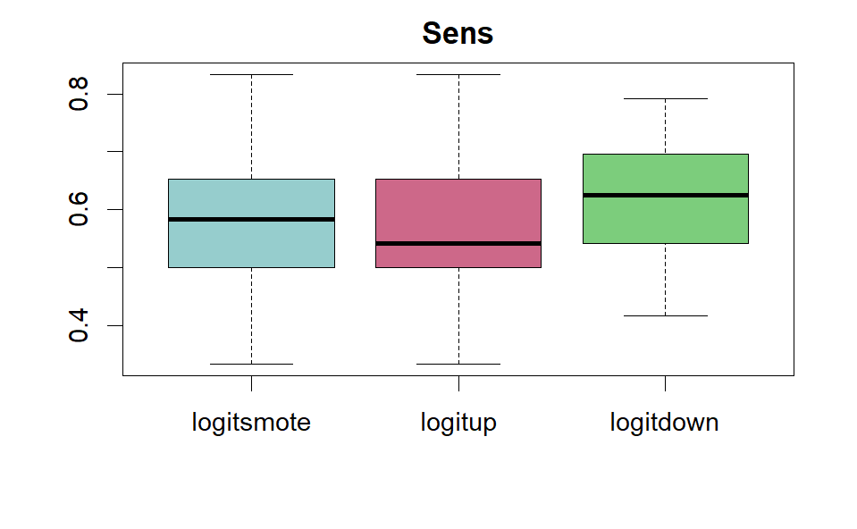

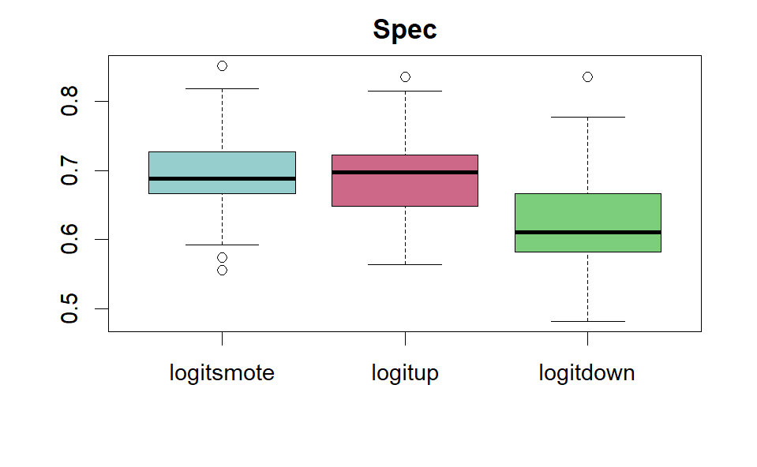

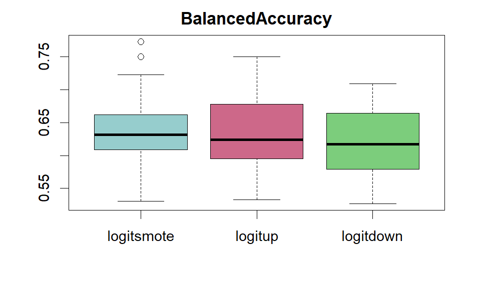

Le résultat sur le groupe de test:

|  | Accuracy | Sensitivity | Specificity | Kappa |
| --- | --- | --- | --- | --- |
| Logit SMOTE | 0.6834 | 0.5696 | 0.7333 | 0.2886 |
| Logit Up | 0.6911 | 0.6203 | 0.7222 | 0.3198 |
| Logit Down | 0.6525 | 0.6203 | 0.6667 | 0.2593 |

Sur la base de l’application du modèle de prédiction au groupe de traitement, le modèle logitdown présente une sensibilité médiane plus élevée et la plus faible variance de sensibilité par rapport aux autres modèles. Cependant, selon le critère de spécificité, le modèle logitdown est moins bon que les autres modèles. Les résultats pour les deux sont diamétralement opposés, nous avons donc envisagé d’utiliser le critère de précision équilibrée afin de prendre en compte à la fois la spécificité et la sensibilité. Dans la boîte de *Balanced Acuuracy*, nous pouvons voir que le modèle logitsmote est le meilleur modèle, malgré il existe certaine valeur aberrante, logitsmote a une variance de la précision équilibrée plus faible que logitup et une valeur médiane de la précision équilibrée plus élevée que logitdown.

## 3.3 KNN

Notre deuxième classe de modèles sont des modèles KNN (K plus proches voisins) avec différent techniques qui traite des déséquilibres. Pour construire les modèles KNN, il faut trouver la valeur de paramètre K optimale. Nous construirons des modèles KNN sur les données d’apprentissage dans une grille de K. Une fois les modèles sont estimés dans les grilles qu’on a défini, nous choisissons le k qui maximise les métriques ROC et précision(accuracy). Ces deux métriques qui servent à définir K optimale sont choisis puisque quand nous utilisons les K optimales maximisant d’autre métriques, les résultats dans les matrices de confusion sont moins bien. Nous avons normalisé les variables dans tous les modèles KNN.

Pour les modèles KNN avec algorithme smote et up sampling, nous avons choisi une grille entre 5 et 50 après plusieurs essais de différentes grilles, et une grille entre 50 et 120 sont choisi pour le modèle avec down sampling. Comme nous avons choisis deux métriques pour définir le paramètre K, nous aurons deux modèles pour chaque méthode corrigeant les déséquilibres de nos données, donc six modèle KNN au total. Finalement, nous avons le modèle smote avec K qui maximise ROC (K = 30), le modèle smote avec K qui maximise précision (K = 5), le modèle up sampling avec K qui maximise ROC (K = 15), le modèle up sampling avec K qui maximise précision (K = 50), le modèle down sampling avec K qui maximise ROC (K = 65.55556), le modèle down sampling avec K qui maximise précision (K = 112.22222)

Les Boîte à moustaches ci-dessous comparent les sensitivité, spécificité, précision équilibrée des six modèles KNN sur les données d’apprentissage.

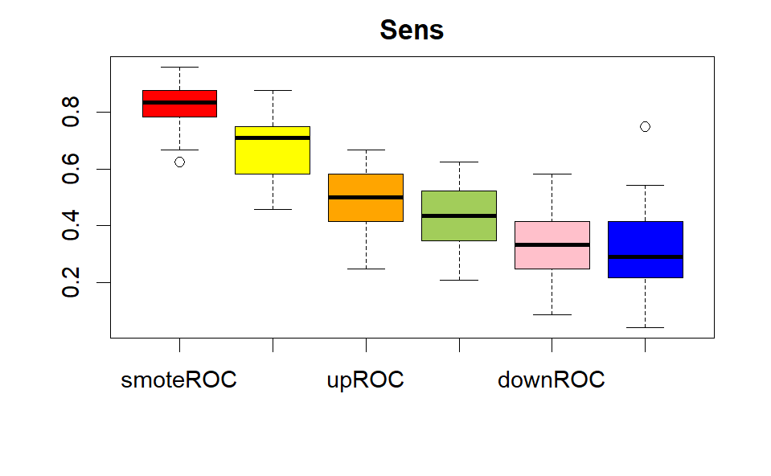

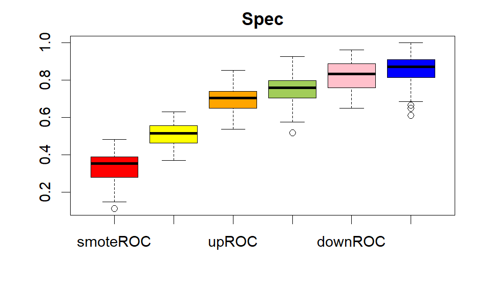

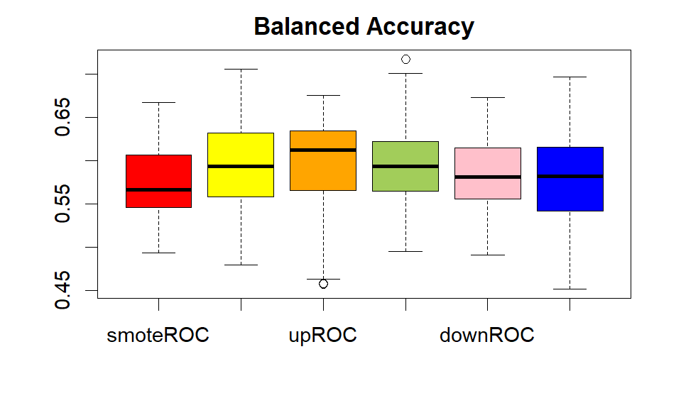

Le modèle KNN smote avec paramètre K maximisant ROC présente une sensibilité la plus forte, mais une spécificité le plus faible. Avec la volonté d’avoir équilibre entre les métriques, nous considérons le modèle smote avec paramètre K maximisant précision comme le modèle favori. Parce que nous pensons toujours que la sensibilité est plus importante pour nous, le deuxième modèle présente une sensibilité la deuxième plus élevée et la spécificité est un peu plus élevée que le premier modèle. La sensibilité du troisième modèle n’est pas assez élevée.

Les résultats principaux dans les matrices de confusion des six modèles utilisés sur les données de test sont résumés dans la table dessous, analysons ces résultats avant de faire la décision.

|  | Accuracy | Sensitivity | Specificity | Kappa |
| --- | --- | --- | --- | --- |
| KNN SMOTE roc | 0.4903 | 0.7468 | 0.3778 | 0.0939 |
| KNN SMOTE accuracy | 0.5946 | 0.6203 | 0.5833 | 0.1755 |
| KNN Up roc | 0.6293 | 0.4937 | 0.6889 | 0.1727 |
| KNN Up accuracy | 0.7336 | 0.4810 | 0.8444 | 0.3412 |
| KNN Down roc | 0.7413 | 0.31646 | 0.92778 | 0.2859 |
| KNN Down accuracy | 0.7181 | 0.2278 | 0.9333 | 0.1951 |

Des conclusions similaires à ceux qu’on obtient avec les données d’apprentissage peuvent obtenir, le modèle 1presente toujours la sensibilité la plus élevée et le modèle 2 la deuxième, mais le modèle 2 ayant une spécificité beaucoup plus élevée que le premier modèle. Les autres modèles dont la sensibilité est inférieure à 0,5 n’ont pas été pris en compte.

Par conséquent, le modèle KNN smote avec K maximisant la précision est choisi, et cela va être compareré aux autres méthodes de classification à la fin.

## 3.4 Random Forest

Nous allons maintenant appliquer nos données au modèle de forêt aléatoire. Lorsque nous utilisons des arbres de décision, Lorsqu’on utilise des arbres de décision, nous observons souvent que la performance du modèle a un faible biais mais une grande variance en raison de la petite taille des observations dans les feuilles terminales dues au grand nombre de paramètres utilisés. Pour résoudre ce problème de grande variance, nous pouvons utiliser le bagging ou la forêt aléatoire.

La méthode de la forêt aléatoire est un ensemble d’arbres, basé sur la validation croisée, et nous allons répéter la prédiction 50 fois, de sorte que nous pouvons considérer la règle de la majorité comme la classe de prédiction finale. Comme nous considérons les résultats de prédiction combinés de nombreux arbres, la forêt aléatoire a moins de variance que la méthode de l’arbre de décision. Il en va de même pour l’algorithme de Bagging, c’est-à-dire qu’il utilise également la moyenne pour réduire la variance. Cependant, les différents arbres de décision de cet algorithme sont liés entre eux car ils utilisent généralement les mêmes prédicteurs, surtout s’il existe des prédicteurs forts. Par conséquent, nous avons finalement décidé d’utiliser la méthode de la forêt aléatoire, qui nous permet de décorréler les arbres. La forêt aléatoire utilise seulement m des p prédicteurs pour chaque nœud, où m est inférieur à p, choisis aléatoirement dans chaque division. Lorsque l’on utilise la validation croisée pour sélectionner des paramètres, il est courant d’utiliser $m \approx\sqrt{p}$ dans la classification.

Dans notre cas, cela correspondrait à environ 5 ou 6 variables. L’approche de la forêt aléatoire fonctionne bien avec des données équilibrées, nous estimons donc le modèle en utilisant trois méthodes différentes d’équilibrage des données : SMOTE, up-sampling et down-sampling.

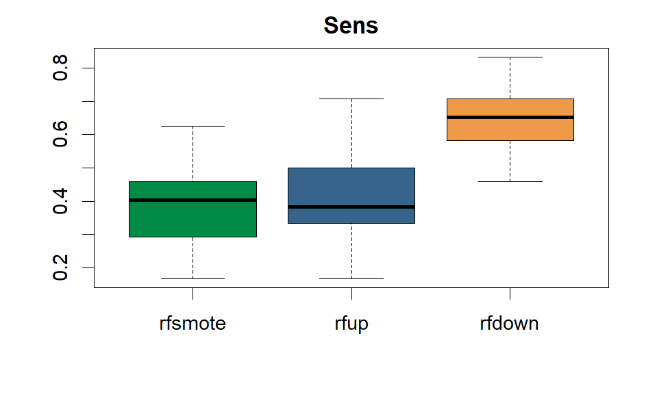

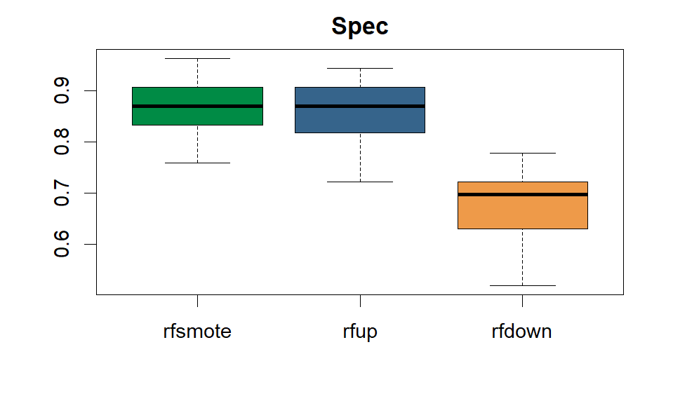

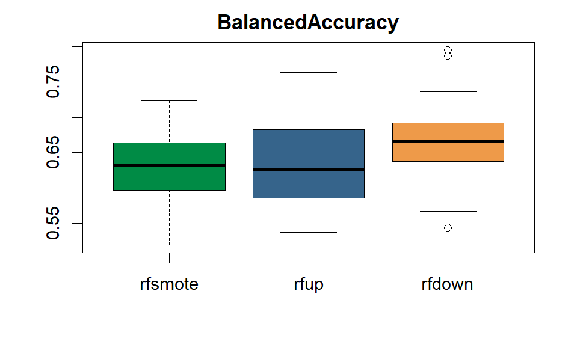

Matrice des résultats pour le groupe test:

|  | Accuracy | Sensitivity | Specificity | Kappa |
| --- | --- | --- | --- | --- |
| RF SMOTE | 0.749 | 0.3671 | 0.9167 | 0.324 |
| RF Up | 0.7606 | 0.3924 | 0.9222 | 0.3578 |
| RF Down | 0.6911 | 0.5949 | 0.7333 | 0.3106 |

## 3.5 SVM

SVM（Support vector machine）est une méthode d’apprentissage supervisé avec des algorithmes d’apprentissage associés qui analysent les données pour la discrimination ou l’analyse de régression. Nous allons donc l’utiliser pour analyser notre problématique de classifier la consommation d’alcool chez les adolescents. Cette méthode détermine des hyperplans à marge maximale pour séparer deux classes. La marge est la distance de chaque point à l’hyperplan. Les points situés à une distance minimale de l’hyperplan sont appelés les vecteurs de support.

Afin de traiter les cas où les données ne sont pas linéairement séparables, le SVM permet de transformer l’espace de représentation des données d’entrée en un espace de dimension supérieure (éventuellement infini), dans lequel une séparation linéaire est susceptible d’exister. Ceci est réalisé par une fonction noyau. Les choix populaires de noyau sont noyau linéaire, noyau polynomial, noyau radial. Nous allons utiliser seulement le noyau linéaire. Puisque l’utilisation du noyau radial et polynomial demande un rcvtunes plus élevés, les résultats obtenus avec un rcvtunes plus élevé (100) nous a permis de sortir les résultats des 3 modèle de différent type de noyaux, cependant, leur performance sont moins bien que le modèle de noyau linéaire avec rcvtunes niveau 10 qui a été utilisé pour tous les modèle. Par conséquent, nous allons construire des modèle SVM de noyau linéaire avec smote, up sampling, et down sampling.

Voici les diagrammes en boîte comparant les métriques sensitivité, spécificité des trois modèles SVM linéaire avec les données d’apprentissage.

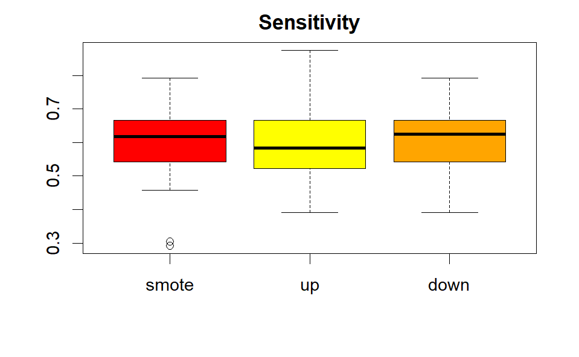

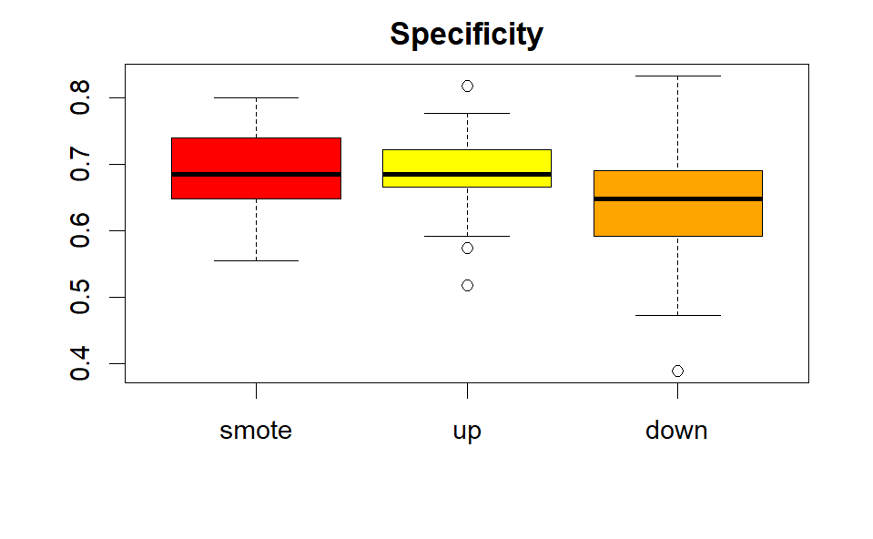

Intuitivement, d’après ces diagrammes en boîte, la différence de sensibilité entre les trois modèles n’est pas très significative, tous se situant autour de 0,6. Le down sampling présente une spécificité moins fort que les deux autres. Peut-être que smote et up seraient meilleurs que down, voyons les résultats sur les données de test pour faire la décision.

La performance de ces modèles utilisant les données de test est résumée dans le tableau ci-dessous.

|  | Accuracy | Sensitivity | Specificity | Kappa |
| --- | --- | --- | --- | --- |
| Linear SVM SMOTE | 0.7143 | 0.5949 | 0.7667 | 0.3492 |
| Linear SVM Up | 0.6718 | 0.5949 | 0.7056 | 0.2796 |
| Linear SVM Down | 0.6525 | 0.6709 | 0.6444 | 0.2778 |

Nous constatons que le down est maintenant plus fort en sensibilité que les deux autres modèles, mais que la spécificité est la plus faible. Au niveau de sensibilité, smote est identique à celle de up, mais smote performe mieux dans tous les autres métriques. Donc le smote est meilleure que up. En combinant les résultats des box plots, nous avons choisi l’approche smote pour le modèle SVM linéaire. Nous allons le comparer avec autres modèles de classification.

## 3.6 Stochastic Gradient Boosting

Nous utiliserons aussi le Stochastic Gradient boosting dans notre projet. Le boosting est une méthode itérative d’apprentissage en général. Il n’est pas facile de mesurer à partir d’un modèle complexe, donc le boosting réduit le biais du modèle en utilisant itérativement un modèle très simple (tel qu’une spline, un arbre ou un knn, dans ce cas un arbre simple) comme “weak learner”. Nous appliquons ensuite ce modèle simple plusieurs fois jusqu’à ce qu’un critère d’arrêt soit atteint. À chaque étape, le modèle actuel corrigera les faiblesses du modèle précédent en donnant un poids plus élevé aux observations qui ont été mal classées par le modèle précédent.

De plus, l’algorithme mesure le gradient local de la fonction de coût pour un ensemble donné de paramètres et suit la direction de la descente du gradient. Le minimum est atteint lorsque le gradient est nul. Dans ce cas, la vitesse d’apprentissage est un paramètre important pour le boosting. Si la vitesse d’apprentissage est trop faible, l’algorithme aura besoin de plusieurs itérations pour trouver le minimum et prendra donc beaucoup de temps à calculer. D’autre part, si la vitesse d’apprentissage est trop élevée, la valeur minimale peut être sautée, ce qui entraîne un sur-apprentissage. Nous avons choisi *shrinkage = 0,6* comme la vitesse d’apprentissage.

Pour réduire la sensibilité du modèle aux valeurs aberrantes, le Stochastic Gradient boosting introduit une composante aléatoire en utilisant un *bag.fraction* inferieur à un, ce qui signifie qu’à chaque étape d’apprentissage, il ne travaille que sur une fraction des observations sélectionnées aléatoirement.

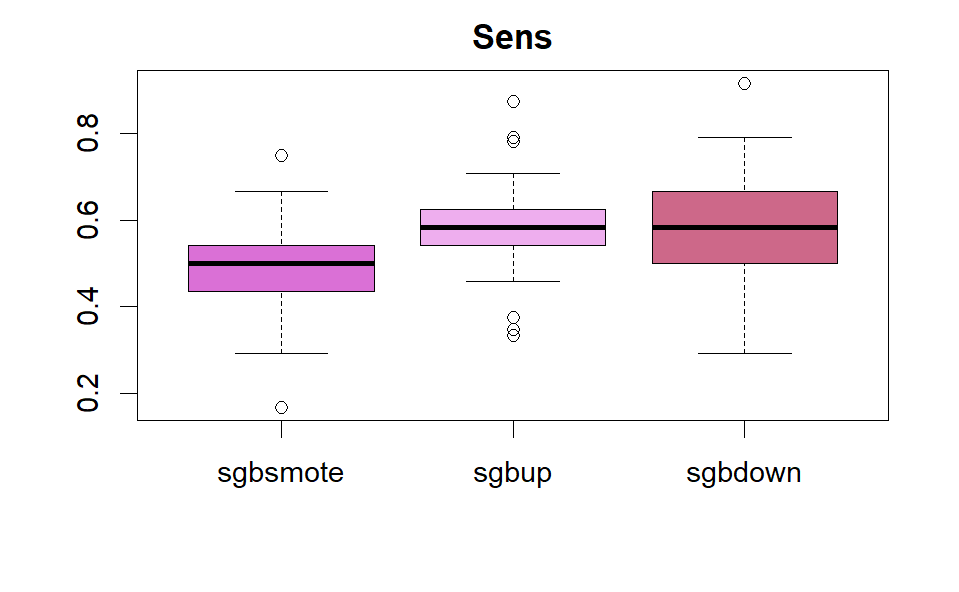

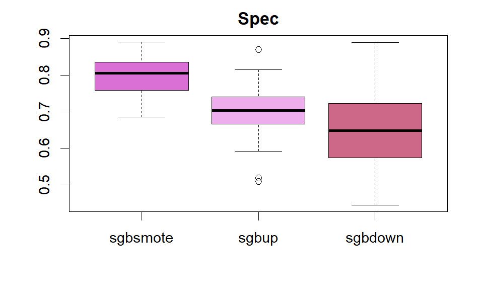

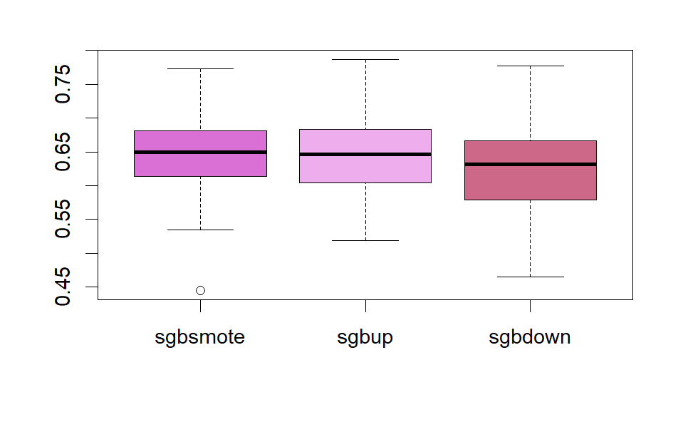

Matrice des résultats pour le groupe test:

|  | Accuracy | Sensitivity | Specificity | Kappa |
| --- | --- | --- | --- | --- |
| Sgb SMOTE | 0.7487 | 0.5546 | 0.8339 | 0.396 |
| Sgb Up | 0.7513 | 0.6975 | 0.7749 | 0.4461 |
| Sgb Down | 0.7282 | 0.5462 | 0.8081 | 0.356 |

Nous préférons le modèle sgb up parce que sa précision et son kappa sont meilleurs que les deux autres modèles, bien que la valeur de la spécificité soit plus petite que les deux autres modèles, mais comme expliqué précédemment, les faux négatifs ont un impact plus important sur l’effet de l’étude que les faux positifs, nous choisissons donc sgb up comme modèle préféré en termes de sensibilité.

## 3.7 Comparaison de la performance des modèles

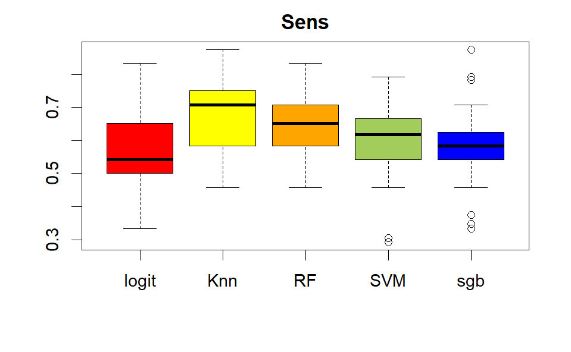

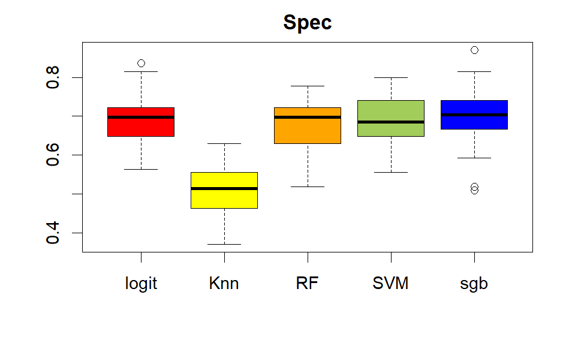

Le modèle KNN smote a une sensibilité très élevée mais une spécificité la plus faible. Encore une fois, nous sommes plus intéressés par la sensibilité, mais nous voulons aussi que l’autre métrique ne soit pas très faible. Donc, ce modèle Knn na va pas être choisi. Les autres modèles ne sont pas aussi nettement supérieurs les uns aux autres. Il semble logique de choisir l’un ou l’autre.

|  | Accuracy | Sensitivity | Specificity | Kappa |
| --- | --- | --- | --- | --- |
| Logit Up | 0.6911 | 0.6203 | 0.7222 | 0.3198 |
| KNN SMOTE accuracy | 0.5946 | 0.6203 | 0.5833 | 0.1755 |
| RF Down | 0.6911 | 0.5949 | 0.7333 | 0.3106 |
| Linear SVM SMOTE | 0.7143 | 0.5949 | 0.7667 | 0.3492 |
| Sgb Up | 0.7513 | 0.6975 | 0.7749 | 0.4461 |

Les 15 variables les plus importantes dans le modèle SGB up sampling sont présentées ci-dessous.

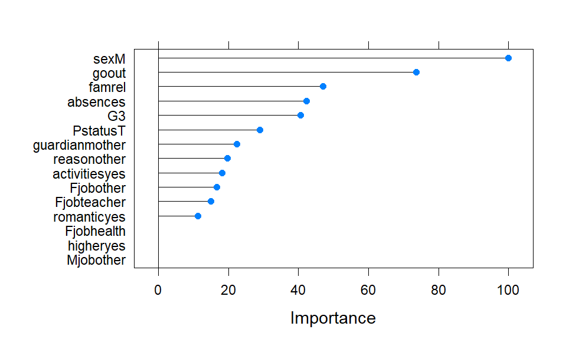

Les 5 variables les plus importantes sont le sexe (masculin), la fréquence de sorties avec amis, la relation familiale, le nombre d’absences scolaires, la note finale d’élève. Ce sont les variables qui peuvent aider à prédire si l’adolescent va boire.

Intuitivement, si les écoles veulent prendre des mesures préventives pour réduire le comportement des élèves en matière de consommation d’alcool, elles peuvent se concentrer sur les garçons qui sèchent plus souvent les cours, qui sont enclins à avoir un comportement alcoolique, et les notes des élèves méritent également qu’on y prête attention. Parmi les variables restantes, nous avons constaté que la plupart d’entre elles étaient des variables familiales concernant les parents des élèves, telles que le statut de cohabitation des parents, le travail des parents, de sorte que la famille est un facteur important influençant le comportement de consommation d’alcool des adolescents et que les parents peuvent avoir une influence significative sur leurs enfants. Les écoles peuvent améliorer la communication avec les parents.

# 4 Conclusion

L‘objectif de cet article est de trouver un modèle approprié qui classe bien notre variable d’intérêt (la consommation d’alcool des adolescents), puis d’analyser ses résultats pour trouver les variables qui affectent le comportement de consommation des élèves. Nous avons décidé de comparer cinq modèles de classification différents (logit, knn, random forest, svm, sgb). En raison du problème de déséquilibre de classe, 3 méthodes d’équilibrage (smote, up, down) traitant le problème de déséquilibre sont implémentés sur chacun de ces cinq types de modèle de classification. Nous avons dans un premier temps sélectionné la meilleure méthode d’équilibrage de classe pour chaque méthode de classification et ensuite le compare avec d’autre méthodes de classification à la fin. Le modèle Stochastic Gradient Boosting avec up sampling est choisi comme le plus performant.

Pour ce modèle choisi, la variable du sexe est la plus importante, les garçons étant enclins à boire, en accord avec Radovanovic et al, (2016). L’importance de certaines variables telles que le travail parental est également similaire à celle trouvée par Droomers et al., (2003). Addresse, la variable indiquant si les étudiants venaient de zones rurales ou urbaines n’apparaissait pas dans la liste des 15 plus importantes variables de notre modèle, contrairement à ce que Radovanovic et al., (2016) a trouvé, indiquant que les adolescents des zones urbaines étaient plus susceptibles de boire de l’alcool. L’émergence de l’importance de la variable note finale rejoint les résultats de Mason et Windle(2001) et Radovanovic et al. (2016), qui ont conclu qu’une excellente note et la consommation d’alcool sont inversement liées.

L’interaction entre adolescents est également un facteur important, comme en témoigne la deuxième variable la plus importante, la fréquence des sorties entre amis. Ceci rejoint la conclusion de Fletcher (2012) et Martino et al. (2009), l’influence des pairs sont importantes.

Il y a certaines limites dans les données, ce questionnaire a été conçu pour étudier les performances des élèves et bien qu’il contienne des variables relatives à l’alcool, il n’a pas de variables plus ciblées à notre problématique, donc s’il y avait des questionnaires plus ciblés, des variables telles que le comportement des parents en matière de consommation d’alcool, les attitudes des étudiants envers l’alcool, la performance de notre modèle pourrait. D’autre part, la quantité de données n’était pas beaucoup, une plus grande quantité de données aurait pu aider le modèle à devenir plus précis avec les méthodes d’apprentissage statistique.

# 5 Bibliographie

Afzali, M. H., Sunderland, M., Stewart, S., Masse, B., Seguin, J., Newton, N., … & Conrod, P. (2019). Machine‐learning prediction of adolescent alcohol use: A cross‐study, cross‐cultural validation. Addiction, 114(4), 662-671.

Bachman, J. G., Schulenberg, J. E., Freedman-Doan, P., O’Malley, P. M., Johnston, L. D., & Messersmith, E. E. (2008). The education-drug use connection: How successes and failures in school relate to adolescent smoking, drinking, drug use, and delinquency. Psychology Press.

Bryant, A. L., Schulenberg, J. E., O’Malley, P. M., Bachman, J. G., & Johnston, L. D. (2003). How academic achievement, attitudes, and behaviors relate to the course of substance use during adolescence: A 6‐year, multiwave national longitudinal study. Journal of research on adolescence, 13(3), 361-397.

Fletcher, J. M. (2012). Peer influences on adolescent alcohol consumption: evidence using an instrumental variables/fixed effect approach. Journal of Population Economics, 25(4), 1265-1286.

Han, M. A., Kim, K. S., Ryu, S. Y., Kang, M. G., & Park, J. (2009). Associations between smoking and alcohol drinking and suicidal behavior in Korean adolescents: Korea Youth Behavioral Risk Factor Surveillance, 2006. Preventive medicine, 49(2-3), 248-252.

Mason, W. A., & Windle, M. (2001). Family, religious, school and peer influences on adolescent alcohol use: a longitudinal study. Journal of studies on alcohol, 62(1), 44-53.

Martino, S. C., Ellickson, P. L., & McCaffrey, D. F. (2009). Multiple trajectories of peer and parental influence and their association with the development of adolescent heavy drinking. Addictive behaviors, 34(8), 693.

Oei, T. P., & Morawska, A. (2004). A cognitive model of binge drinking: The influence of alcohol expectancies and drinking refusal self-efficacy. Addictive behaviors, 29(1), 159-179.

Pyhtila. J.(2021) Teen Drinking Facts and Statistics https://www.therecoveryvillage.com/teen-addiction/alcohol/teen-drinking-stats/

World Health Organization. (2010). Global strategy to reduce the harmful use of alcohol. World Health Organization.

# 6 Annexes

Figures: Représentation de la relation entre la variables d’intérêt et les variables explicatives qualitatives.

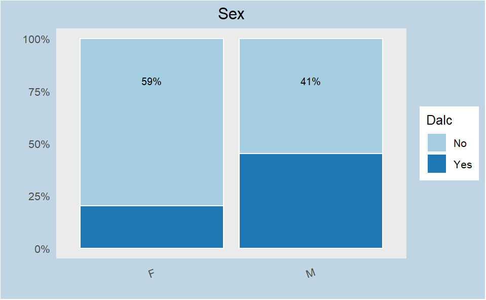

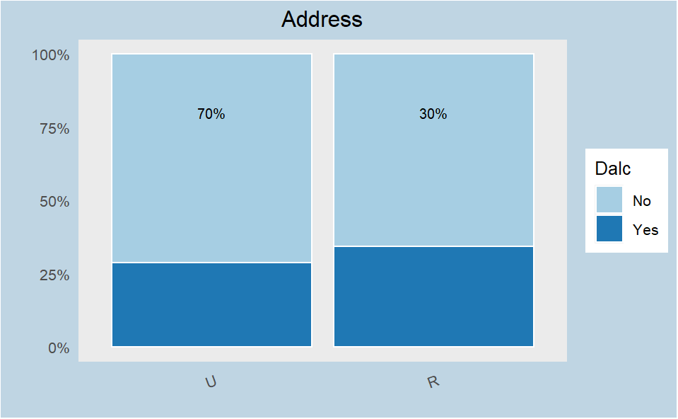

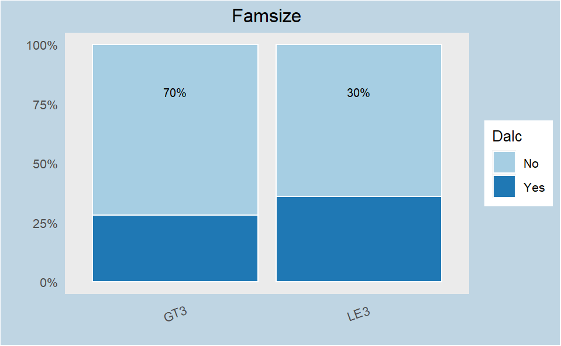

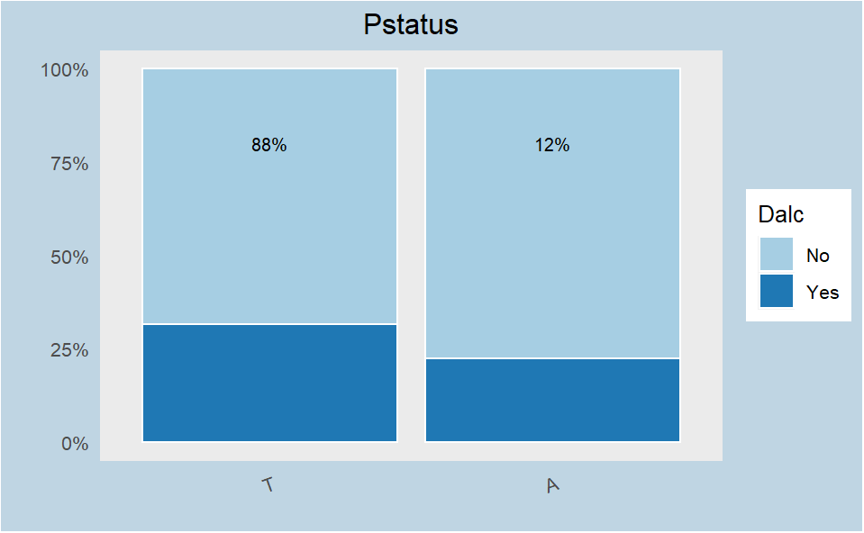

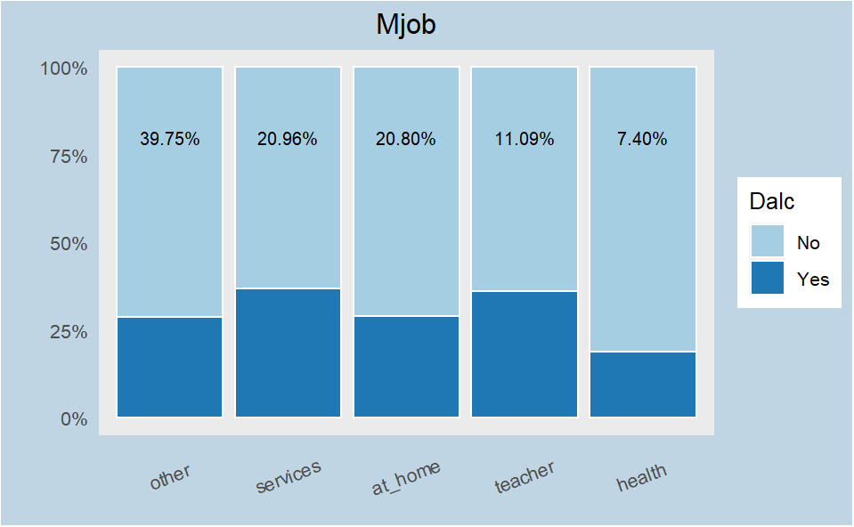

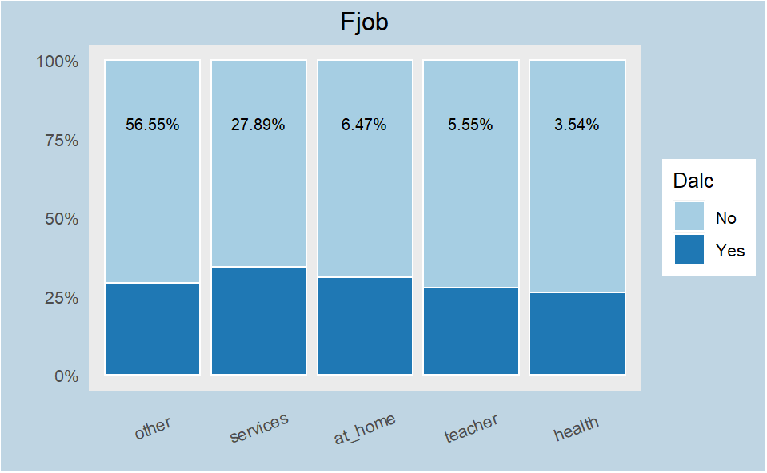

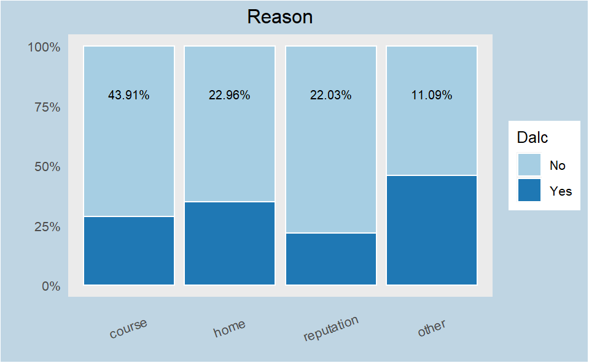

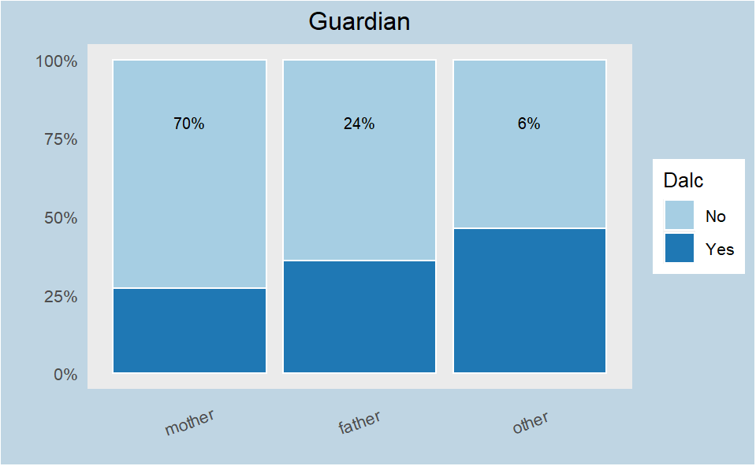

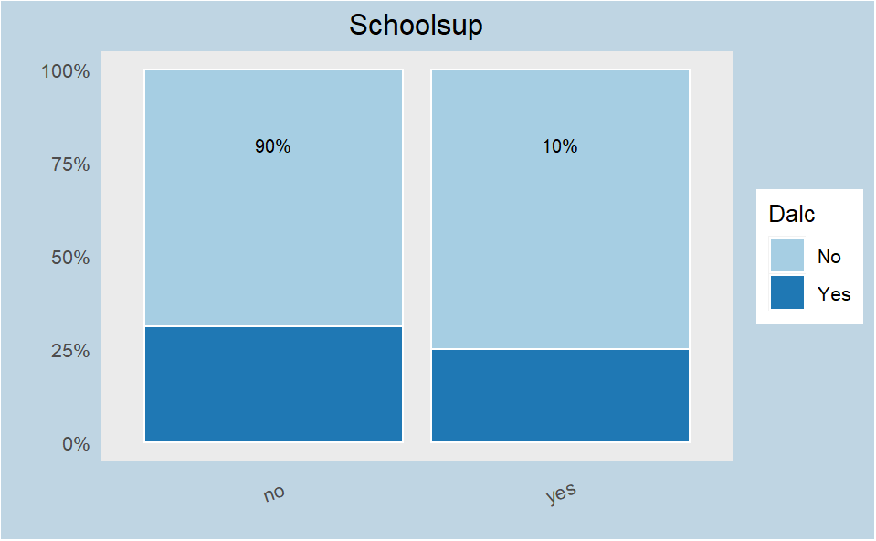

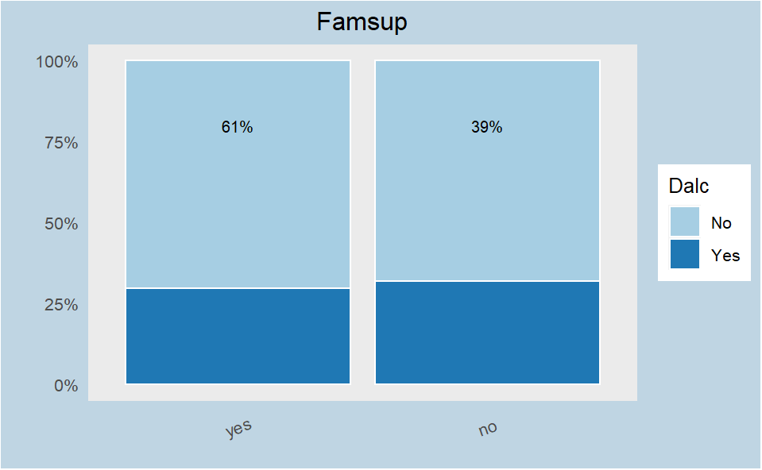

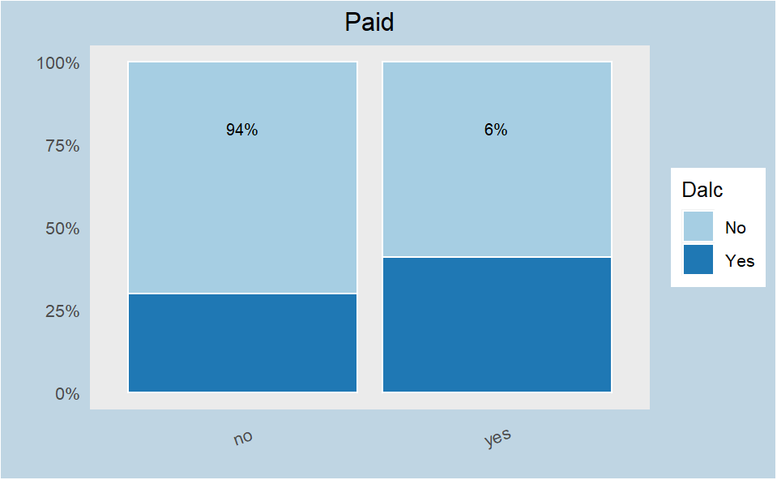

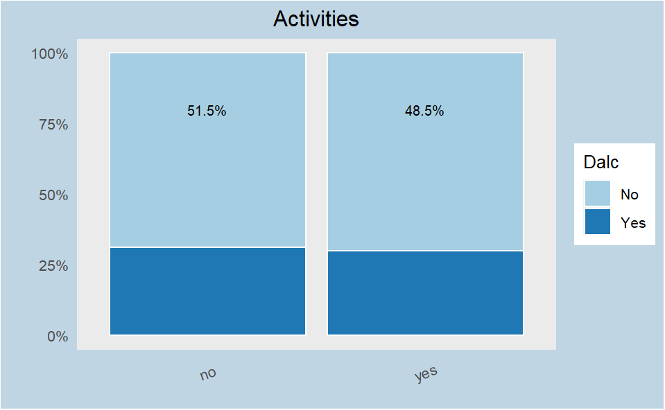